# 1-1. 데이터 전처리

```python
import pandas as pd
import numpy as np
import matplotlib.pyplot as plt
import matplotlib
import seaborn as sns
from sklearn.preprocessing import StandardScaler
from sklearn.model_selection import train_test_split
from statsmodels.api import Logit
from sklearn.metrics import accuracy_score,f1_score
from sklearn.metrics import confusion_matrix, classification_report
from sklearn.tree import DecisionTreeRegressor
from sklearn.ensemble import RandomForestRegressor
from sklearn.metrics import mean_squared_error
from sklearn.metrics import mean_absolute_error
from sklearn.ensemble import GradientBoostingRegressor
from sklearn.linear_model import LinearRegression
from sklearn.feature_selection import RFE
import pandas as pd
import statsmodels.formula.api as smf
from statsmodels.stats.outliers_influence import variance_inflation_factor
import matplotlib.pyplot as plt
import matplotlib
from sklearn.tree import export_graphviz
import graphviz
from sklearn.model_selection import train_test_split
from sklearn.tree import DecisionTreeClassifier
from sklearn.svm import SVC
from sklearn.model_selection import GridSearchCV
from sklearn.metrics import accuracy_score,f1_score
from sklearn.metrics import confusion_matrix, classification_report
from sklearn.neural_network import MLPClassifier
from sklearn.ensemble import RandomForestClassifier
from sklearn.ensemble import RandomForestRegressor
from sklearn.ensemble import GradientBoostingRegressor
from sklearn.ensemble import GradientBoostingClassifier
from sklearn.neural_network import MLPClassifier
from sklearn.metrics import precision_score, recall_score, f1_score,roc_curve, auc
from statsmodels.api import qqplot, add_constant
from sklearn.decomposition import PCA
import statsmodels.api as sm
```

```python
# 리눅스 폰트 적용
%matplotlib inline

import platform
platform.platform()

import sys
sys.version_info

!apt-get install -y fonts-nanum
!ls -l /usr/share/fonts/truetype/
!rm -rf ~/.cache/matplotlib/*
!fc-cache -fv

import matplotlib
import matplotlib.font_manager
[f.name for f in matplotlib.font_manager.fontManager.ttflist if 'Nanum' in f.name]

import matplotlib as mpl
mpl.rcParams['axes.unicode_minus'] = False
plt.rcParams["font.family"] = 'NanumGothic'
```

[output not shown]

[output cut: 132 more lines]

[output not shown]

```python
df = pd.read_csv('bigdata/new_telco_customer.csv')
df.drop(columns='Unnamed: 0', inplace=True)
df.head()
```

|  | CustomerId | Gender | Age | AgeGroup | Married | Dependents | noDependents | Referrals | noReferrals | PaperlessBilling | ... | CustomerLTV | SatisScore | TotalExtraDataCharge | AvgRoamCharge | TotalRoamCharge | TotalCharge | AvgCharge | TotalRevenue | TenureMonths | noService |
| --- | --- | --- | --- | --- | --- | --- | --- | --- | --- | --- | --- | --- | --- | --- | --- | --- | --- | --- | --- | --- | --- |
| 0 | C-10001 | 여성 | 37 | 30대 | Yes | No | 0 | Yes | 2 | Yes | ... | 2205 | 3 | 0 | 47910 | 431100 | 1755400 | 83590 | 2186500 | 21 | 2 |
| 1 | C-10002 | 남성 | 46 | 40대 | No | No | 0 | No | 0 | No | ... | 5414 | 5 | 11300 | 12090 | 108710 | 1447500 | 68928 | 1567510 | 21 | 0 |
| 2 | C-10003 | 남성 | 50 | 50대 | No | No | 0 | No | 0 | Yes | ... | 4479 | 1 | 0 | 38080 | 152100 | 490900 | 98180 | 643000 | 4 | 0 |
| 3 | C-10004 | 남성 | 78 | 70대 | Yes | No | 0 | Yes | 1 | Yes | ... | 3714 | 1 | 0 | 31410 | 408720 | 1578400 | 112742 | 1987120 | 13 | 1 |
| 4 | C-10005 | 여성 | 75 | 70대 | Yes | No | 0 | Yes | 3 | Yes | ... | 3464 | 1 | 0 | 8360 | 24970 | 378000 | 94500 | 402970 | 3 | 1 |

5 rows × 33 columns

```python
df.describe()
```

|  | Age | noDependents | noReferrals | AvgDownloadGB | ChurnScore | CustomerLTV | SatisScore | TotalExtraDataCharge | AvgRoamCharge | TotalRoamCharge | TotalCharge | AvgCharge | TotalRevenue | TenureMonths | noService |
| --- | --- | --- | --- | --- | --- | --- | --- | --- | --- | --- | --- | --- | --- | --- | --- |
| count | 6863.000000 | 6863.000000 | 6863.000000 | 6863.000000 | 6863.000000 | 6863.000000 | 6863.000000 | 6863.000000 | 6863.000000 | 6.863000e+03 | 6.863000e+03 | 6863.000000 | 6.863000e+03 | 6863.000000 | 6863.000000 |
| mean | 46.606877 | 0.411482 | 1.990675 | 20.507358 | 58.133324 | 4412.442372 | 3.278304 | 7916.421390 | 25966.319394 | 8.674697e+05 | 3.423892e+06 | 76482.821361 | 4.299278e+06 | 42.201952 | 0.939677 |
| std | 16.581750 | 0.879672 | 3.024032 | 20.424957 | 21.408509 | 1180.383953 | 1.188723 | 28684.745619 | 17477.405921 | 9.601166e+05 | 3.008542e+06 | 35527.411892 | 3.659638e+06 | 26.455574 | 1.018413 |
| min | 20.000000 | 0.000000 | 0.000000 | 0.000000 | 5.000000 | 2003.000000 | 1.000000 | 0.000000 | 0.000000 | 0.000000e+00 | 4.240000e+04 | 20807.000000 | 4.590000e+04 | 1.000000 | 0.000000 |
| 25% | 32.000000 | 0.000000 | 0.000000 | 3.000000 | 40.000000 | 3487.000000 | 3.000000 | 0.000000 | 10400.000000 | 9.441500e+04 | 9.770000e+05 | 42284.500000 | 1.272825e+06 | 18.000000 | 0.000000 |
| 50% | 46.000000 | 0.000000 | 0.000000 | 17.000000 | 60.000000 | 4538.000000 | 3.000000 | 0.000000 | 25990.000000 | 4.860100e+05 | 2.310800e+06 | 83194.000000 | 3.156600e+06 | 39.000000 | 1.000000 |
| 75% | 60.000000 | 0.000000 | 3.000000 | 27.000000 | 75.000000 | 5388.000000 | 4.000000 | 0.000000 | 41250.000000 | 1.379790e+06 | 5.482450e+06 | 106070.000000 | 6.683200e+06 | 67.000000 | 2.000000 |
| max | 80.000000 | 4.000000 | 11.000000 | 85.000000 | 100.000000 | 6500.000000 | 5.000000 | 169500.000000 | 56500.000000 | 4.028110e+06 | 1.167510e+07 | 140905.000000 | 1.553714e+07 | 84.000000 | 3.000000 |

## 데이터 전처리

### 결측치

```python
df.isna().sum()
```

```
CustomerId                 0
Gender                     0
Age                        0
AgeGroup                   0
Married                    0
Dependents                 0
noDependents               0
Referrals                  0
noReferrals                0
PaperlessBilling           0
PaymentMethod              0
OnlineSecurity             0
OnlineBackup               0
TechSupport                0
UnlimitedData              0
AvgDownloadGB              0
StartDate                  0
EndDate                 5161
EndDateTmp                 0
ChurnLabel                 0
ChurnScore                 0
ChurnCategory           5161
ChurnReason             5161
CustomerLTV                0
SatisScore                 0
TotalExtraDataCharge       0
AvgRoamCharge              0
TotalRoamCharge            0
TotalCharge                0
AvgCharge                  0
TotalRevenue               0
TenureMonths               0
noService                  0
dtype: int64
```

- 이탈하지 않은 고객의 경우 EndDate, ChurnCategory, ChurnReason가 조사되지 않았다.

### 이상치

```python
# numeric, discrete 나누기
df_index = df[['Age','noDependents','noReferrals','AvgDownloadGB','CustomerLTV','ChurnScore','SatisScore','TotalExtraDataCharge','AvgRoamCharge','TotalRoamCharge']]
```

```
Age                        AxesSubplot(0.125,0.125;0.065678x0.755)
noDependents            AxesSubplot(0.203814,0.125;0.065678x0.755)
noReferrals             AxesSubplot(0.282627,0.125;0.065678x0.755)
AvgDownloadGB           AxesSubplot(0.361441,0.125;0.065678x0.755)
CustomerLTV             AxesSubplot(0.440254,0.125;0.065678x0.755)
ChurnScore              AxesSubplot(0.519068,0.125;0.065678x0.755)
SatisScore              AxesSubplot(0.597881,0.125;0.065678x0.755)
TotalExtraDataCharge    AxesSubplot(0.676695,0.125;0.065678x0.755)
AvgRoamCharge           AxesSubplot(0.755508,0.125;0.065678x0.755)
TotalRoamCharge         AxesSubplot(0.834322,0.125;0.065678x0.755)
dtype: object
```

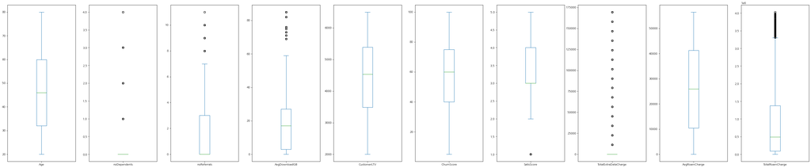

```python
# 이상치 확인을 위한 boxplot
df_index.plot(kind='box', figsize=(50,10), subplots=True, sharex=False,sharey=False)
```

```python
def get_outlier(df=None, column = None, weight = 1.5): # IQR을 사용하여 이상치를 확인하기 위해 함수 생성
    quantile_25 = np.percentile(df[column].values, 25) # 1사분위수 생성
    quantile_75 = np.percentile(df[column].values, 75) # 3사분위수 생성

    iqr = quantile_75  - quantile_25 # IQR = Q3 - Q1
    iqr_w = iqr*weight # 1.5*IQR

    lowest = quantile_25 - iqr_w # MIN 기준 -> Q1 - 1.5*IQR
    highest = quantile_75 + iqr_w # MAX 기준 -> Q3 + 1.5IQR

    outlier_idx = df[column][ (df[column] < lowest) | (df[column] > highest)].index # 각 컬럼에서 이상치 인덱스만 뽑음
    return outlier_idx
```

```python
# IQR로 확인한 이상치의 index
for i in df_index.columns.values:
    print(get_outlier(df_index, column =i)) # 각 column 별 이상치 index
```

```
Int64Index([], dtype='int64')
Int64Index([   5,    9,   11,   15,   16,   22,   25,   26,   28,   33,
            ...
            6824, 6831, 6834, 6838, 6841, 6847, 6848, 6851, 6852, 6854],
           dtype='int64', length=1453)
Int64Index([   7,   15,   25,   31,   54,   58,   59,   63,   64,   68,
            ...
            6728, 6737, 6750, 6777, 6785, 6798, 6806, 6819, 6824, 6834],
           dtype='int64', length=675)
Int64Index([   5,   49,   54,   58,  104,  107,  119,  128,  149,  155,
            ...
            6570, 6594, 6665, 6668, 6676, 6681, 6770, 6772, 6793, 6794],
           dtype='int64', length=353)
Int64Index([], dtype='int64')
Int64Index([], dtype='int64')
Int64Index([   2,    3,    4,   18,   21,   24,   52,   53,   62,   84,
            ...
            6826, 6827, 6830, 6832, 6833, 6840, 6843, 6856, 6857, 6859],
           dtype='int64', length=847)
Int64Index([   1,    7,   25,   48,   49,   53,   69,   79,  107,  110,
            ...
            6786, 6787, 6793, 6808, 6809, 6814, 6833, 6837, 6847, 6854],
           dtype='int64', length=717)
Int64Index([], dtype='int64')
Int64Index([  79,   92,  149,  151,  191,  251,  265,  315,  354,  390,
            ...
            6321, 6376, 6404, 6489, 6511, 6577, 6753, 6814, 6838, 6848],
           dtype='int64', length=178)
```

### 분포와 특성을 확인하기 위한 히스토그램

```python
df_index = df[['Age','noDependents','noReferrals','AvgDownloadGB','CustomerLTV','ChurnScore','SatisScore','TotalExtraDataCharge','AvgRoamCharge','TotalRoamCharge','TenureMonths','AvgCharge','TotalCharge','TotalRevenue']]
df_pie = df.drop(columns = ['Age','noDependents','noReferrals','AvgDownloadGB','CustomerLTV','ChurnScore','SatisScore','TotalExtraDataCharge','AvgRoamCharge','TotalRoamCharge','TenureMonths','AvgCharge','TotalCharge','TotalRevenue'])
```

```python
df_pie.drop(columns = ['StartDate','EndDate','EndDateTmp','ChurnReason','CustomerId'], inplace=True)
```

```python
df_pie.columns
```

```
Index(['Gender', 'AgeGroup', 'Married', 'Dependents', 'Referrals',
       'PaperlessBilling', 'PaymentMethod', 'OnlineSecurity', 'OnlineBackup',
       'TechSupport', 'UnlimitedData', 'ChurnLabel', 'ChurnCategory',
       'noService'],
      dtype='object')
```

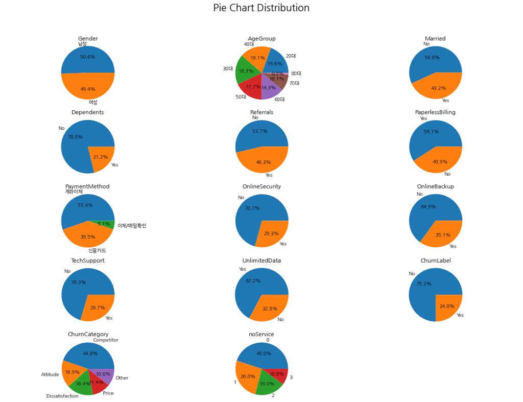

```python
# pie chart
fig = plt.figure(figsize = (15,12))
plt.suptitle('Pie Chart Distribution', fontsize = 20)
for i in range(1, df_pie.shape[1]+1):
    plt.subplot(5,3,i) #17개 열
    f = plt.gca()
    f.axes.get_yaxis().set_visible(False) # y라벨을 제거해 그래프에 너무 많은 내용이 들어가지 않게
    f.set_title(df_pie.columns.values[i-1])

    #vals = np.size(dataset2.iloc[:, i-1].unique()) 파이차트에서 필요 없지!

    # pie chart 첫번 째 인자 values = 크기를 의미하는 값, # 두번쨰 인자 : label을 위해 #3번째 인자 : 분포값을 어떻게 표시할지
    values = df_pie.iloc[:, i-1].value_counts(normalize = True).values
    index = df_pie.iloc[:, i-1].value_counts(normalize = True).index
    plt.pie(values, labels = index, autopct='%1.1f%%')
    plt.axis('equal') # 이렇게 지정시 이미지에 x혹은 y축이 표시되지 않습니다.

plt.tight_layout(rect=[0,0.03,1,0.95]) # 각 하위 그래프 직사각형 크기를 지정해 겹치지 않게함
plt.show()
```

ChurnCategory -> 이탈한 이유 항목들 중 competitor 항목이 약45%로 가장 많이 차지

competitor의 churnreason을 분석해야지

```python
df_hist=df.drop(columns = ['CustomerId','ChurnReason','ChurnCategory','StartDate','EndDate','EndDateTmp'])
```

```python
df_hist.values
```

```
array([['여성', 37, '30대', ..., 2186500, 21, 2],
       ['남성', 46, '40대', ..., 1567510, 21, 0],
       ['남성', 50, '50대', ..., 643000, 4, 0],
       ...,
       ['남성', 22, '20대', ..., 834440, 14, 1],
       ['남성', 21, '20대', ..., 6488960, 79, 2],
       ['남성', 36, '30대', ..., 5196100, 75, 2]], dtype=object)
```

```python
def sub_hist(df, var, x, y):
    axes[x][y].hist(df[df["ChurnLabel"] == 'Yes'][var], label="churn", alpha=0.5)
    axes[x][y].hist(df[df["ChurnLabel"] == 'No'][var], label="nochurn", alpha=0.5)
    axes[x][y].set_xlabel(var)
```

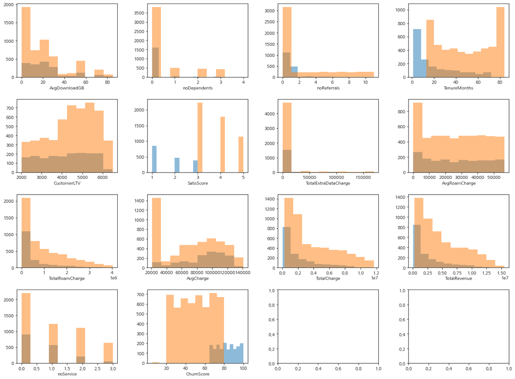

```python
f, axes = plt.subplots(4, 4)

# 격자 크기 설정
f.set_size_inches((20, 15))

# 격자 여백 설정
plt.subplots_adjust(wspace = 0.3, hspace = 0.3)

sub_hist(df, "AvgDownloadGB", 0, 0)
sub_hist(df, "noDependents", 0, 1)
sub_hist(df, "noReferrals", 0, 2)
sub_hist(df, "TenureMonths", 0, 3)
sub_hist(df, "CustomerLTV", 1, 0)
sub_hist(df, "SatisScore", 1, 1)
sub_hist(df, "TotalExtraDataCharge", 1, 2)
sub_hist(df, "AvgRoamCharge", 1, 3)
sub_hist(df, "TotalRoamCharge", 2, 0)
sub_hist(df, "AvgCharge", 2, 1)
sub_hist(df, "TotalCharge", 2, 2)
sub_hist(df, "TotalRevenue", 2, 3)
sub_hist(df, "noService", 3, 0)
sub_hist(df, "ChurnScore", 3, 1)

plt.show()
```

churn nochurn 구분되어 그려진 histogram 아래에서 하나하나 분석

```python
def fun_plot_hist(data, var):
    plt.hist(data[data["ChurnLabel"] == 'No'][var], label="NoChurn", alpha=0.5)
    plt.hist(data[data["ChurnLabel"] == 'Yes'][var], label="Churn", alpha=0.5)
    plt.legend()
```

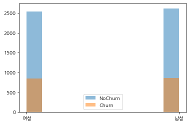

```python
fun_plot_hist(df_hist, 'Gender')
```

여성과 남성간 이탈률이 차이가 없음 -> 삭제 ( 목표변수와 상관분석 후 삭제요망 )

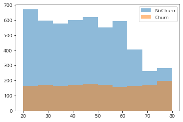

```python
fun_plot_hist(df_hist, 'Age')
```

- 나이가 많을 수록 이탈률이 증가

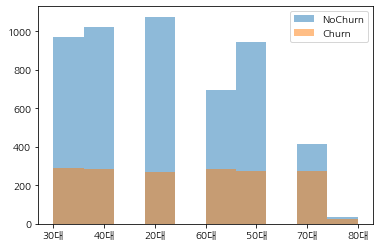

```python
fun_plot_hist(df_hist, 'AgeGroup')
```

'Age' 와 같이 연령대가 높을 수록 이탈률이 증가

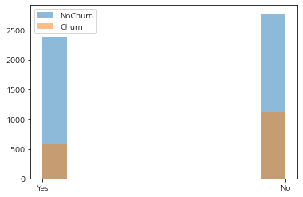

```python
fun_plot_hist(df_hist, 'Married')
```

미혼이면 이탈률이 높음

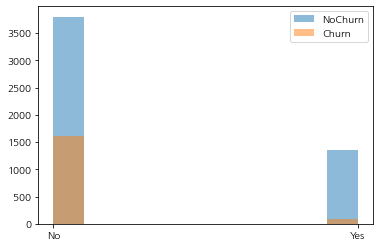

```python
fun_plot_hist(df_hist, 'Dependents')
```

- 부양자가 없으면 이탈률이 높음

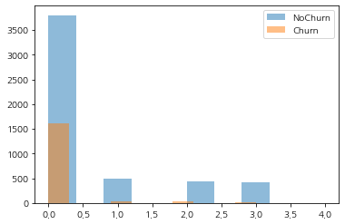

```python
fun_plot_hist(df_hist, 'noDependents')
```

- 'Dependents' 와 같은 맥락으로 부양자의 수가 적을 수록 이탈률이 높음

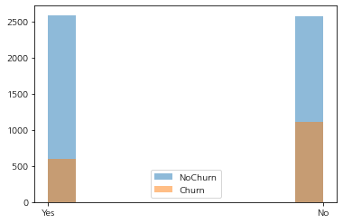

```python
fun_plot_hist(df_hist, 'Referrals')
```

추천을 안한 사람이 이탈률이 더 높음

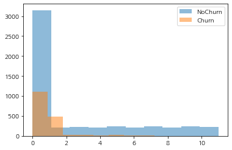

```python
fun_plot_hist(df_hist, 'noReferrals')
```

2번이상 추천한 사람들은 이탈률이 매우 낮음

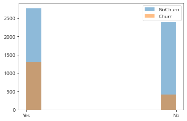

```python
fun_plot_hist(df_hist, 'PaperlessBilling')
```

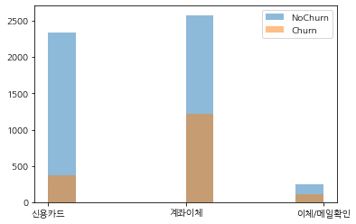

```python
fun_plot_hist(df_hist, 'PaymentMethod')
```

신용카드를 사용하는 사람들이 계좌,이체/메일확인하는 사람에 대비하여 이탈률이 낮음

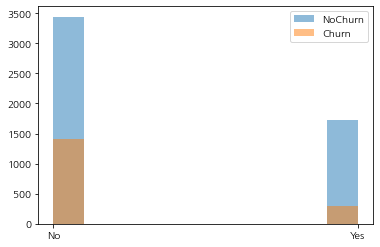

```python
fun_plot_hist(df_hist, 'OnlineSecurity')
```

OnlineSecurity를 사용하지 않는 사람일 수록 이탈률 높음

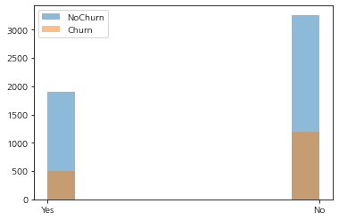

```python
fun_plot_hist(df_hist, 'OnlineBackup')
```

OnlineBackup의 서비스 사용 유무는 이탈률에 크게 영향을 주지않음

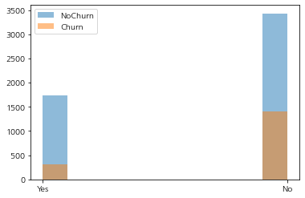

```python
fun_plot_hist(df_hist, 'TechSupport')
```

TechSupport를 사용하지 않을 수록 이탈률이 높음

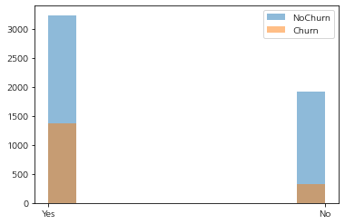

```python
fun_plot_hist(df_hist, 'UnlimitedData')
```

데이터를 무제한 사용할 수록 이탈률이 높음

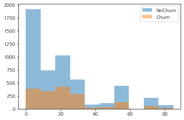

```python
fun_plot_hist(df_hist, 'AvgDownloadGB')
```

AvgDownloadGB는 상대적으로 10gb이상 사용자들이 이탈률이 높다 판단, but 분포가 비슷하여 큰 영향 없을 것으로 판단

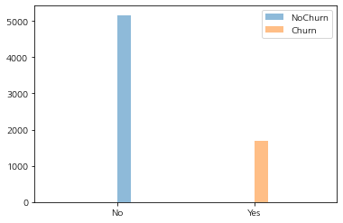

```python
fun_plot_hist(df_hist, 'ChurnLabel')
```

목표변수입니다!

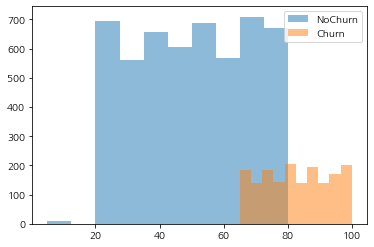

```python
fun_plot_hist(df_hist, 'ChurnScore')
```

- churnscore가 약 80점 이상는 무조건 이탈

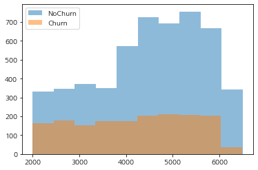

```python
fun_plot_hist(df_hist, 'CustomerLTV')
```

LTV점수가 약 3800 이하에서 이탈률이 높음

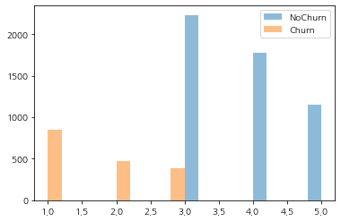

```python
fun_plot_hist(df_hist, 'SatisScore')
```

- 만족도 점수 1점,2점은 이탈 확실

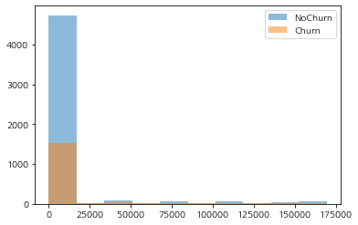

```python
fun_plot_hist(df_hist, 'TotalExtraDataCharge')
```

```
(0.0, 100.0)
```

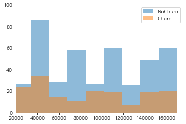

```python
fun_plot_hist(df_hist, 'TotalExtraDataCharge')
plt.xlim([20000,175000])
plt.ylim([0,100])
```

TotalExtraDataCharge 20000이상 부분을 크게 해봄 -> 2만원, 9~10만원 때의 이탈률이 높아보임

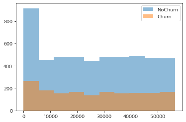

```python
fun_plot_hist(df_hist, 'AvgRoamCharge')
```

평균 로밍금액이 5000원 넘어가면 이탈률이 상대적으로 높지만 유의미할 것 같지 않음

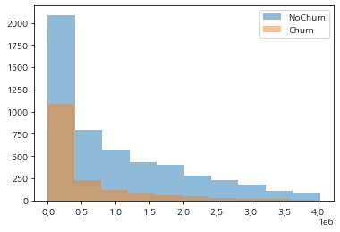

```python
fun_plot_hist(df_hist, 'TotalRoamCharge')
```

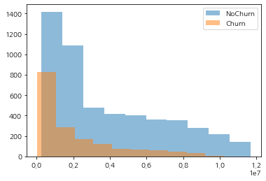

```python
fun_plot_hist(df_hist, 'TotalCharge')
```

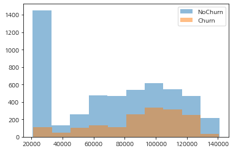

```python
fun_plot_hist(df_hist, 'AvgCharge')
```

평균 과금금액이 80000원 이상일 때 큰 이탈률 보임

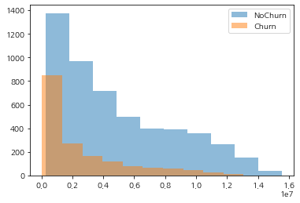

```python
fun_plot_hist(df_hist, 'TotalRevenue')
```

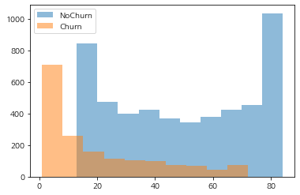

```python
fun_plot_hist(df_hist, 'TenureMonths')
```

사용기간이 약 12개월 이하일 경우 100% 이탈을 보임 이후는 이탈률 줄어듬

### 분석에서 제외할 변수 찾기

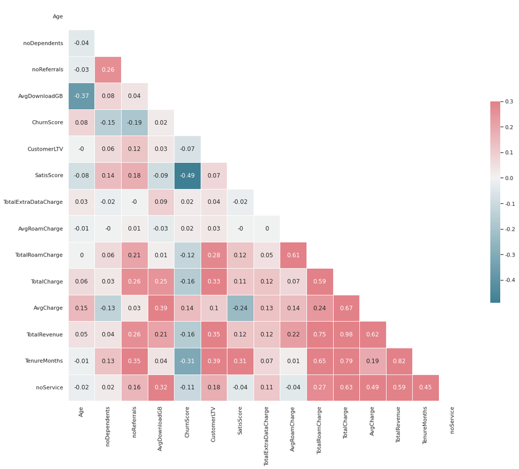

```python
# correlation matrix
sns.set(style="white")

# Compute the correlation matrix
corr = df.corr().round(2)

# Generate a mask for the upper triangle
mask = np.zeros_like(corr, dtype=np.bool)
mask[np.triu_indices_from(mask)] = True

# Set up the matplotlib figure
f, ax = plt.subplots(figsize=(18, 15))

# Generate a custom diverging colormap
cmap = sns.diverging_palette(220, 10, as_cmap=True)

# Draw the heatmap with the mask and correct aspect ratio
sns.heatmap(corr, mask=mask, cmap=cmap, vmax=.3, center=0,
            square=True, linewidths=.5, cbar_kws={"shrink": .5}, annot = True)
```

`CustomerId`: 인덱스 변수 -> 분석에 의미 없음 -> 삭제  
`Gender`: 히스토그램에서 차이없었음 -> 목표변수와 상관관계분석 후 확신할거야 -> 삭제  
`AgeGroup: Age & AgeGroup` 상관관계 높을 것이라 예상 -> 두 변수 상관관계 분석 후 확신할거야 -> 삭제  
`Dependents: Dependents & noDependents`: 상관관계 높을 것이라 예상 -> 두 변수 상관관계 분석 후 확신할거야 -> 삭제  
`Referrals`: Referrals & Referrals -> 상관관계 높을 것이라 예상 -> 두 변수 상관관계 분석 후 확신할거야 -> 삭제  
`OnlineSecurity & OnlineBackup & TechSupport`: 0.초기데이터 파일에서 파생변수 `noService 생성` -> 상관관계 있다고 확신할거야 -> 삭제  
`StartDate & EndDate & EndDateTmp`: 0.초기데이터 파일에서 파생변수 `TenureMonths 생성` -> 날짜데이터 분석불가 -> 삭제  
`TotalCharge`: (TotalCharge & AvgCharge) (TotalCharge & TotalRevenue) 상관관계 높을 것이라 예상 -> 두 변수 상관관계 분석 후 확신할거야 -> 삭제 `SatisScore`: 위 히스토그램에서 확인했듯이, 스코어가 3인 고객들만 churn nochurn 공존 -> 과적합요소라 생각할거야 -> 삭제  
`ChurnCategory & ChurnReason`: churn한 고객들만 응답한 설문으로 따로 제외하여 분석할거야 -> 삭제

#### 변수를 제외하기 위한 상관분석

```python
from scipy.stats import chi2_contingency
print('귀무가설 : 성별과 churnlabel간 상관관계가 없다 ')
print('대립가설 : 상관관계가 있다')
chi_res  = chi2_contingency(pd.crosstab(df['Gender'], df['ChurnLabel']))
print('Chi2 Statistic: {}, p-value: {}'.format(chi_res[0], chi_res[1]))
print()
print('p-value > 0.05 이므로 귀무가설 채택 -> 목표변수와 상관관계가 없다 -> 삭제')
```

```
귀무가설 : 성별과 churnlabel간 상관관계가 없다
대립가설 : 상관관계가 있다
Chi2 Statistic: 0.13384706678057595, p-value: 0.7144761467274232

p-value > 0.05 이므로 귀무가설 채택 -> 목표변수와 상관관계가 없다 -> 삭제
```

귀무가설 : Age와 AgeGroup간 상관관계가 없다  
대립가설 : 상관관계가 있다

```python
print('귀무가설 : Age와 AgeGroup간 상관관계가 없다')
print('대립가설 : 상관관계가 있다')
chi_res  = chi2_contingency(pd.crosstab(df['Age'], df['AgeGroup']))
print('Chi2 Statistic: {}, p-value: {}'.format(chi_res[0], chi_res[1]))
print()
print('p-value < 0.05 으로 귀무가설 기각 -> 상관관계가 있다')
```

```
귀무가설 : Age와 AgeGroup간 상관관계가 없다
대립가설 : 상관관계가 있다
Chi2 Statistic: 41178.0, p-value: 0.0

p-value < 0.05 으로 귀무가설 기각 -> 상관관계가 있다
```

```python
print('귀무가설 : Dependents와 noDependents간 상관관계가 없다')
print('대립가설 : 상관관계가 있다')
chi_res  = chi2_contingency(pd.crosstab(df['Dependents'], df['noDependents']))
print('Chi2 Statistic: {}, p-value: {}'.format(chi_res[0], chi_res[1]))
print('')
print('p-value < 0.05 으로 귀무가설 기각 -> 상관관계가 있다')
```

```
귀무가설 : Dependents와 noDependents간 상관관계가 없다
대립가설 : 상관관계가 있다
Chi2 Statistic: 6863.000000000001, p-value: 0.0

p-value < 0.05 으로 귀무가설 기각 -> 상관관계가 있다
```

```python
print('귀무가설 : Referrals와 noReferrals간 상관관계가 없다')
print('대립가설 : 상관관계가 있다')
chi_res  = chi2_contingency(pd.crosstab(df['Referrals'], df['noReferrals']))
print('Chi2 Statistic: {}, p-value: {}'.format(chi_res[0], chi_res[1]))
print('')
print('p-value < 0.05 으로 귀무가설 기각 -> 상관관계가 있다')
```

```
귀무가설 : Referrals와 noReferrals간 상관관계가 없다
대립가설 : 상관관계가 있다
Chi2 Statistic: 6863.0, p-value: 0.0

p-value < 0.05 으로 귀무가설 기각 -> 상관관계가 있다
```

```python
print('귀무가설 : TechSupport와 OnlineBackup간 상관관계가 없다')
print('대립가설 : 상관관계가 있다')
chi_res  = chi2_contingency(pd.crosstab(df['TechSupport'], df['OnlineBackup']))
print('Chi2 Statistic: {}, p-value: {}'.format(chi_res[0], chi_res[1]))
print('')
print('p-value < 0.05 으로 귀무가설 기각 -> 상관관계가 있다')
```

```
귀무가설 : TechSupport와 OnlineBackup간 상관관계가 없다
대립가설 : 상관관계가 있다
Chi2 Statistic: 575.4476556689142, p-value: 3.6670341308694935e-127

p-value < 0.05 으로 귀무가설 기각 -> 상관관계가 있다
```

```python
print('귀무가설 : TechSupport와 OnlineSecurity간 상관관계가 없다')
print('대립가설 : 상관관계가 있다')
chi_res  = chi2_contingency(pd.crosstab(df['TechSupport'], df['OnlineSecurity']))
print('Chi2 Statistic: {}, p-value: {}'.format(chi_res[0], chi_res[1]))
print('')
print('p-value < 0.05 으로 귀무가설 기각 -> 상관관계가 있다')
```

```
귀무가설 : TechSupport와 OnlineSecurity간 상관관계가 없다
대립가설 : 상관관계가 있다
Chi2 Statistic: 844.0311692712082, p-value: 1.4428065388559134e-185

p-value < 0.05 으로 귀무가설 기각 -> 상관관계가 있다
```

```python
print('귀무가설 : OnlineSecurity와 OnlineBackup간 상관관계가 없다')
print('대립가설 : 상관관계가 있다')
chi_res  = chi2_contingency(pd.crosstab(df['OnlineSecurity'], df['OnlineBackup']))
print('Chi2 Statistic: {}, p-value: {}'.format(chi_res[0], chi_res[1]))
print('')
print('p-value < 0.05 으로 귀무가설 기각 -> 상관관계가 있다')
```

```
귀무가설 : OnlineSecurity와 OnlineBackup간 상관관계가 없다
대립가설 : 상관관계가 있다
Chi2 Statistic: 536.5042657341876, p-value: 1.086242165993485e-118

p-value < 0.05 으로 귀무가설 기각 -> 상관관계가 있다
```

```python
print('귀무가설 : TotalCharge와 TotalRevenue간 상관관계가 없다')
print('대립가설 : 상관관계가 있다')
chi_res  = chi2_contingency(pd.crosstab(df['TotalCharge'], df['TotalRevenue']))
print('Chi2 Statistic: {}, p-value: {}'.format(chi_res[0], chi_res[1]))
print('')
print('p-value < 0.05 으로 귀무가설 기각 -> 상관관계가 있다')
```

```
귀무가설 : TotalCharge와 TotalRevenue간 상관관계가 없다
대립가설 : 상관관계가 있다
Chi2 Statistic: 44455654.41666604, p-value: 1.7886271864289365e-07

p-value < 0.05 으로 귀무가설 기각 -> 상관관계가 있다
```

```python
print('귀무가설 : TotalCharge와 AvgCharge간 상관관계가 없다')
print('대립가설 : 상관관계가 있다')
chi_res  = chi2_contingency(pd.crosstab(df['TotalCharge'], df['AvgCharge']))
print('Chi2 Statistic: {}, p-value: {}'.format(chi_res[0], chi_res[1]))
print('')
print('p-value < 0.05 으로 귀무가설 기각 -> 상관관계가 있다')
```

```
귀무가설 : TotalCharge와 AvgCharge간 상관관계가 없다
대립가설 : 상관관계가 있다
Chi2 Statistic: 41672231.31944457, p-value: 0.0

p-value < 0.05 으로 귀무가설 기각 -> 상관관계가 있다
```

모두 확인했으니 완료! 지워보자!

```python
df = df.drop(columns=['CustomerId','Gender','AgeGroup','Dependents','Referrals','OnlineSecurity','OnlineBackup','TechSupport','StartDate','EndDate','EndDateTmp','TotalCharge','SatisScore','ChurnCategory','ChurnReason'])
df.head()
```

|  | Age | Married | noDependents | noReferrals | PaperlessBilling | PaymentMethod | UnlimitedData | AvgDownloadGB | ChurnLabel | ChurnScore | CustomerLTV | TotalExtraDataCharge | AvgRoamCharge | TotalRoamCharge | AvgCharge | TotalRevenue | TenureMonths | noService |
| --- | --- | --- | --- | --- | --- | --- | --- | --- | --- | --- | --- | --- | --- | --- | --- | --- | --- | --- |
| 0 | 37 | Yes | 0 | 2 | Yes | 신용카드 | Yes | 16 | No | 65 | 2205 | 0 | 47910 | 431100 | 83590 | 2186500 | 21 | 2 |
| 1 | 46 | No | 0 | 0 | No | 신용카드 | No | 10 | No | 66 | 5414 | 11300 | 12090 | 108710 | 68928 | 1567510 | 21 | 0 |
| 2 | 50 | No | 0 | 0 | Yes | 계좌이체 | Yes | 30 | Yes | 71 | 4479 | 0 | 38080 | 152100 | 98180 | 643000 | 4 | 0 |
| 3 | 78 | Yes | 0 | 1 | Yes | 계좌이체 | Yes | 4 | Yes | 99 | 3714 | 0 | 31410 | 408720 | 112742 | 1987120 | 13 | 1 |
| 4 | 75 | Yes | 0 | 3 | Yes | 신용카드 | Yes | 11 | Yes | 68 | 3464 | 0 | 8360 | 24970 | 94500 | 402970 | 3 | 1 |

### 범주형 데이터 전처리

```python
# binary 데이터 전처리
df['Married'] = df['Married'].map({'No':0, 'Yes':1})
df['PaperlessBilling'] = df['PaperlessBilling'].map({'No':0, 'Yes':1})
df['UnlimitedData'] = df['UnlimitedData'].map({'No':0, 'Yes':1})
df['ChurnLabel']=df['ChurnLabel'].map({'No':0,'Yes':1})
```

```python
df_proc = pd.get_dummies(df.copy())
```

```python
df_proc
```

|  | Age | Married | noDependents | noReferrals | PaperlessBilling | UnlimitedData | AvgDownloadGB | ChurnLabel | ChurnScore | CustomerLTV | TotalExtraDataCharge | AvgRoamCharge | TotalRoamCharge | AvgCharge | TotalRevenue | TenureMonths | noService | PaymentMethod_계좌이체 | PaymentMethod_신용카드 | PaymentMethod_이체/메일확인 |
| --- | --- | --- | --- | --- | --- | --- | --- | --- | --- | --- | --- | --- | --- | --- | --- | --- | --- | --- | --- | --- |
| 0 | 37 | 1 | 0 | 2 | 1 | 1 | 16 | 0 | 65 | 2205 | 0 | 47910 | 431100 | 83590 | 2186500 | 21 | 2 | 0 | 1 | 0 |
| 1 | 46 | 0 | 0 | 0 | 0 | 0 | 10 | 0 | 66 | 5414 | 11300 | 12090 | 108710 | 68928 | 1567510 | 21 | 0 | 0 | 1 | 0 |
| 2 | 50 | 0 | 0 | 0 | 1 | 1 | 30 | 1 | 71 | 4479 | 0 | 38080 | 152100 | 98180 | 643000 | 4 | 0 | 1 | 0 | 0 |
| 3 | 78 | 1 | 0 | 1 | 1 | 1 | 4 | 1 | 99 | 3714 | 0 | 31410 | 408720 | 112742 | 1987120 | 13 | 1 | 1 | 0 | 0 |
| 4 | 75 | 1 | 0 | 3 | 1 | 1 | 11 | 1 | 68 | 3464 | 0 | 8360 | 24970 | 94500 | 402970 | 3 | 1 | 0 | 1 | 0 |
| ... | ... | ... | ... | ... | ... | ... | ... | ... | ... | ... | ... | ... | ... | ... | ... | ... | ... | ... | ... | ... |
| 6858 | 20 | 0 | 0 | 0 | 0 | 1 | 59 | 0 | 59 | 3161 | 0 | 52770 | 685680 | 64428 | 2296380 | 25 | 2 | 0 | 1 | 0 |
| 6859 | 40 | 1 | 0 | 1 | 1 | 1 | 17 | 1 | 68 | 5248 | 0 | 18310 | 402730 | 101891 | 2746230 | 22 | 0 | 1 | 0 | 0 |
| 6860 | 22 | 0 | 0 | 0 | 1 | 1 | 51 | 0 | 33 | 5870 | 0 | 21020 | 42040 | 56600 | 834440 | 14 | 1 | 0 | 1 | 0 |
| 6861 | 21 | 0 | 0 | 5 | 0 | 1 | 58 | 0 | 59 | 4792 | 0 | 2370 | 160460 | 80107 | 6488960 | 79 | 2 | 0 | 1 | 0 |
| 6862 | 36 | 1 | 0 | 1 | 0 | 1 | 5 | 0 | 20 | 5639 | 0 | 0 | 0 | 69281 | 5196100 | 75 | 2 | 1 | 0 | 0 |

6863 rows × 20 columns

```python
df_proc.dtypes
```

```
Age                      int64
Married                  int64
noDependents             int64
noReferrals              int64
PaperlessBilling         int64
UnlimitedData            int64
AvgDownloadGB            int64
ChurnLabel               int64
ChurnScore               int64
CustomerLTV              int64
TotalExtraDataCharge     int64
AvgRoamCharge            int64
TotalRoamCharge          int64
AvgCharge                int64
TotalRevenue             int64
TenureMonths             int64
noService                int64
PaymentMethod_계좌이체       uint8
PaymentMethod_신용카드       uint8
PaymentMethod_이체/메일확인    uint8
dtype: object
```

### 마무리

csv 파일 업로드

```python
# df_proc.to_csv("proc_telco_customer.csv", mode='w')
```